# Cleaning and Visualizations

## Data Cleaning

Row Filtering: Removed non-participant rows (e.g., “Mean”, “SD”, summary labels) to ensure only valid observations were included.

Data Joining: Merged two data sets using participant IDs to combine behavioral and demographic information.

Column Selection: Dropped unnecessary columns (e.g., extra “x#” variables and personal identifiers) and retained only relevant variables up to delta_building_test.

## Visualization 1

This visualization shows how manual dexterity scores relate to simple reaction time. Each point represents one participant. The horizontal axis shows the participant’s average simple reaction time, while the vertical axis shows their Building Test score, which measures manual dexterity. Participants are separated by sex using different colors and shapes. A trend line is shown for each sex group to make it easier to compare whether the relationship between reaction time and dexterity looks similar or different across groups.

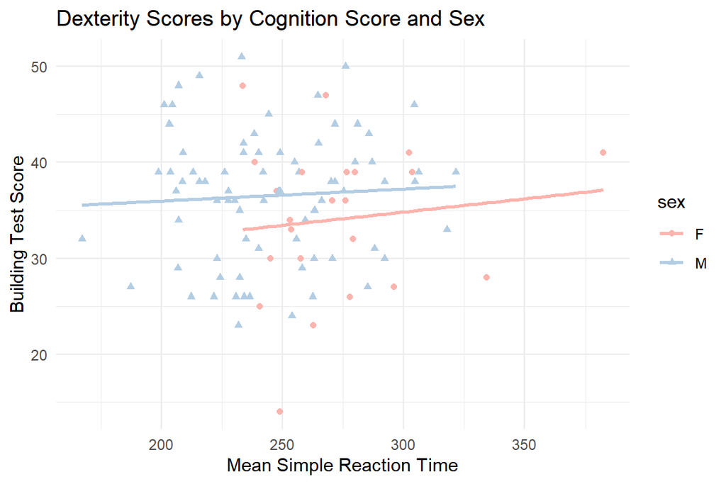

Manual dexterity scores by simple reaction time and sex.

## Visualization 2

This visualization compares how manual dexterity scores changed from the practice test to the actual test for each sex group. The horizontal axis shows the difference between a person’s practice and actual Building Test scores, while the vertical axis separates participants by sex. The shape of each group shows how spread out the score differences are. Wider areas mean more participants had score differences in that range. The box in the middle shows the typical range of score differences for each group. Overall, this visualization helps compare whether one sex group tended to have larger changes in dexterity performance or more variation in scores than the other.

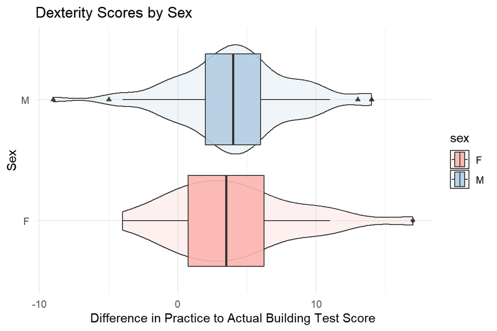

Score of practice to actual manual dexterity scores by sex.